# Assignment 2

Mitheysh Asokan, Jason (Eungjoo) Kim

## Question 1: Nonlinear Regression

## 1.1 Process your data

Dataset chosen: diamonds

Choose the input and output variables.

```r
diamonds <- read.csv('diamonds.csv')
diamonds <- select(diamonds,carat:price)

dim(diamonds)
```

```
## [1] 5000    7
```

```r
head(diamonds)
```

|  | carat | cut | color | clarity | depth | table | price |
| --- | --- | --- | --- | --- | --- | --- | --- |
| 1 | 0.77 | Premium | E | SI1 | 60.4 | 58 | 2975 |
| 2 | 1.51 | Fair | F | I1 | 67.8 | 59 | 3734 |
| 3 | 0.71 | Premium | D | SI1 | 61.7 | 56 | 2863 |
| 4 | 0.90 | Very Good | H | SI1 | 62.3 | 63 | 3387 |
| 5 | 1.00 | Fair | I | SI1 | 67.9 | 62 | 2856 |
| 6 | 0.92 | Very Good | J | SI1 | 62.6 | 58 | 3170 |

Remove all NAs from your data

```r
diamonds <- na.omit(diamonds)

dim(diamonds)
```

```
## [1] 5000    7
```

Downsample if your data is larger than 5000 rows:

```r
diamonds <- diamonds[diamonds$price > 2500,]

dim(diamonds)
```

```
## [1] 4460    7
```

If there are numeric variables that were supposed to be categorical, convert them to categorical

```r
diamonds$cut <- as.factor(diamonds$cut)
diamonds$color <- as.factor(diamonds$color)
diamonds$clarity <- as.factor(diamonds$clarity)
```

## 1.2 train/Test Split

Split your data into train and test using 80/20 ratio. Print number of observations each dataset contains.

```r
set.seed(100)

train_size <- floor(0.8 * nrow(diamonds))
train_inds <- sample(1:nrow(diamonds), size = train_size)
test_inds  <- setdiff(1:nrow(diamonds), train_inds)

train <- diamonds[ train_inds , ]
test  <- diamonds[ test_inds , ]

cat('train size:', nrow(train), '\ntest size:', nrow(test))
```

```
## train size: 3568
## test size: 892
```

## 1.3 Visualize the data

Draw histogram of one of the numeric input variable and the output variable you selected.

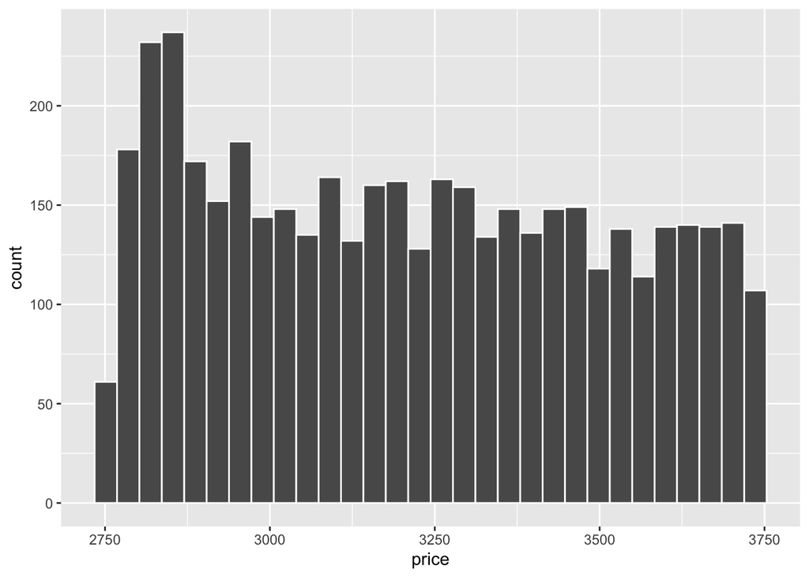

```r
ggplot(data = diamonds) +
  geom_histogram(aes(x = price), color = 'white')
```

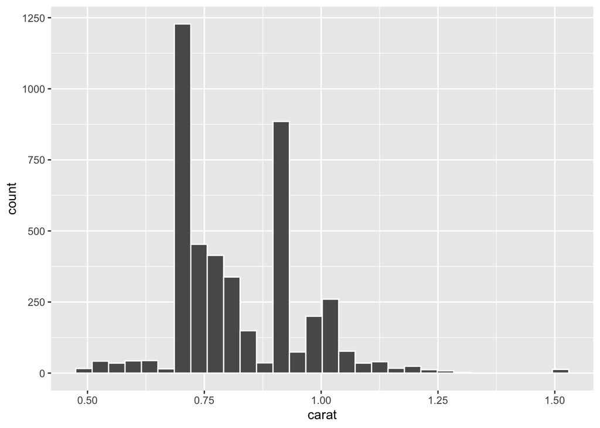

```r
ggplot(data = diamonds) +
  geom_histogram(aes(x = carat), color = 'white')
```

Draw scatter plot between one of your numeric inputs and the output variable.

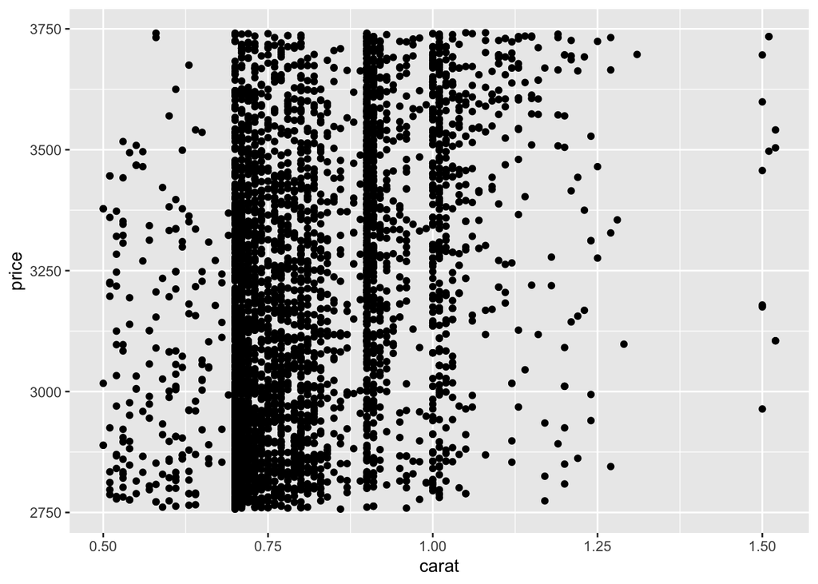

```r
ggplot(data = diamonds) +
  geom_point(aes(x = carat, y = price))
```

Discuss whether the plot indicate a relation, if it is linear, if there are outliers?

The plot definitely hints at some minor relations. According to the diagram, the price of the diamond is increasing with respect to the carat. This is a true statement when compared to real diamond markets, where the carat weight of the diamond tends to partial influence the price of the diamond.

It is hard to definitely claim if the relationship is linear, but an upward sloping linear trend can be slightly observed.

## 1.4 Fit 4 models

One simple linear regression,

```r
fit1 <- lm(price ~ carat, data = train)
```

One multilinear regression with all the variables you selected.

```r
fit2 <- lm(price ~ . , data = train)
```

One polynomial regression using one input variable and one output variable.

```r
fit3 <- lm(price ~ poly(carat,2), data = train)
```

One Locally Weighted Regression using one input numeric input variable and one output variable.

```r
fit4 <- loess(price ~ depth, data = train)
```

Calculate each model’s RMSE on the train set. Which one performed the best and which did worse? Rank the models based on their training error.

Best: Model2

Worst: Model4

Ranking: Model2, Model3, Model1, Model4

```r
sigma(fit1)
```

```
## [1] 269.3641
```

```r
sigma(fit2)
```

```
## [1] 234.5879
```

```r
sigma(fit3)
```

```
## [1] 268.3738
```

```r
pred4 <- predict(fit4)
RMSE(pred4, train$price)
```

```
## [1] 291.9991
```

Calculate each model’s RMSE on the test set. Which one performed the best and which did worse? Rank the models based on their test error.

Best: Model2

Worst: Model4

Ranking: Model2, Model3, Model1, Model4

```r
pred1 <- predict(fit1, newdata=test)
pred2 <- predict(fit2, newdata=test)
pred3 <- predict(fit3, newdata=test)

RMSE(pred1, test$price)
```

```
## [1] 265.4409
```

```r
RMSE(pred2, test$price)
```

```
## [1] 233.0535
```

```r
RMSE(pred3, test$price)
```

```
## [1] 265.2131
```

```r
RMSE(pred4, test$price)
```

```
## [1] 286.1072
```

Did the order of models change when ranked using training and test error?

No.

## 1.5. Cross Validation

Fit the 4 models but train using the cross validation.

```r
train.control <- trainControl(method = 'cv', number = 10)

model1 <- train(price ~ carat, data = diamonds, method = 'lm', trControl = train.control)
model2 <- train(price ~ ., data = diamonds, method = 'lm', trControl = train.control)
model3 <- train(price ~ poly(carat,2), data = diamonds, method = 'lm', trControl = train.control)
model4 <- train(price ~ carat, data = diamonds, method = 'gamLoess', trControl = train.control)

pred1 <- predict(model1, newdata=test)
pred2 <- predict(model2, newdata=test)
pred3 <- predict(model3, newdata=test)
pred4 <- predict(model4, newdata=test)

RMSE(pred1, test$price)
```

```
## [1] 265.0814
```

```r
RMSE(pred2, test$price)
```

```
## [1] 231.9981
```

```r
RMSE(pred3, test$price)
```

```
## [1] 264.7938
```

```r
RMSE(pred4, test$price)
```

```
## [1] 261.1916
```

What is the test error of each resulting model?

Best: Model2

Worst: Model1

Ranking: Model2, Model4, Model3, Model1

```r
pred1 <- predict(model1, newdata=test)
pred2 <- predict(model2, newdata=test)
pred3 <- predict(model3, newdata=test)
pred4 <- predict(model4, newdata=test)

RMSE(pred1, test$price)
```

```
## [1] 265.0814
```

```r
RMSE(pred2, test$price)
```

```
## [1] 231.9981
```

```r
RMSE(pred3, test$price)
```

```
## [1] 264.7938
```

```r
RMSE(pred4, test$price)
```

```
## [1] 261.1916
```

Did the order of models’ test performances change when trained using cross validation?

Yes.

## 1.6. Shrinkage

Fit the first three models (exclude locally weighted model) using ridge regression.

```r
x1 <- model.matrix(price ~ carat, data = diamonds)
x2 <- model.matrix(price ~ ., data = diamonds)
x3 <- model.matrix(price ~ poly(carat,2), data = diamonds)

y <- diamonds$price

fit1 <- glmnet(x1,y,alpha=0)
fit2 <- glmnet(x2,y,alpha=0)
fit3 <- glmnet(x3,y,alpha=0)
```

Calculate RMSE loss on test set.

```r
pred1 <- predict(fit1, newx=x1, newdata=test)
pred2 <- predict(fit2, newx=x2, newdata=test)
pred3 <- predict(fit3, newx=x3, newdata=test)

RMSE(pred1, test$price)
```

```
## [1] 290.3445
```

```r
RMSE(pred2, test$price)
```

```
## [1] 291.6528
```

```r
RMSE(pred3, test$price)
```

```
## [1] 290.5159
```

Fit the first three models (exclude locally weighted model) using lasso regression.

```r
fit4 <- glmnet(x1,y,alpha=1)
fit5 <- glmnet(x2,y,alpha=1)
fit6 <- glmnet(x3,y,alpha=1)
```

Calculate RMSE loss on test set.

```r
pred4 <- predict(fit4, newx=x1, newdata=test)
pred5 <- predict(fit5, newx=x2, newdata=test)
pred6 <- predict(fit6, newx=x3, newdata=test)

RMSE(pred4, test$price)
```

```
## [1] 299.5081
```

```r
RMSE(pred5, test$price)
```

```
## [1] 316.14
```

```r
RMSE(pred6, test$price)
```

```
## [1] 300.0939
```

Which model yielded the minimum test loss? Rank the 6 models.

Minimum Test Loss: Model1

Rankings: Model1, Model3, Model2, Model4, Model6, Model5

## Question 2 Text Classification

### 2.2 Model Fitting

Initial Data Read and Setup

```r
health <- read.csv("mental_health.csv")[,-1]

## 80% of the sample size
smp_size <- floor(0.80 * nrow(health))

## set the seed to make your partition reproducible
set.seed(123)
train_ind <- sample(seq_len(nrow(health)), size = smp_size)

train <- health[train_ind, ]
test <- health[-train_ind, ]

x   <- model.matrix(IsMentalHealthRelated ~ .,train)
y   <- train$IsMentalHealthRelated
```

Determining the optimal labmda values for L1 and L2 regularization

```r
cv.fit  <- cv.glmnet(x,y,alpha=1, family="binomial", nfolds = 10)
cv.fit$lambda.min # 0.002455181

cv.fit  <- cv.glmnet(x,y,alpha=0, family="binomial", nfolds = 10)
cv.fit$lambda.min # 0.02822862
```

Fitting the Models

```r
fit.logreg <- glmnet(x,y,family="binomial")
fit.l1 <- glmnet(x,y,alpha=1,family="binomial", lambda = 0.002455181)
fit.l2 <- glmnet(x,y,alpha=0,family="binomial", lambda = 0.02822862)
```

### 2.3 Performance Comparison

```r
# Model w.o Regularization
newdata_x   <- model.matrix(IsMentalHealthRelated ~ .,test)
probs <- predict(fit.logreg,newdata_x,type = "response")
preds <- ifelse(probs >= 0.5, 1, 0)
target <- ifelse(test$IsMentalHealthRelated == "Yes", 1, 0)
acc1 <- mean(preds == target)

# Model with L1 Regularization
newdata_x   <- model.matrix(IsMentalHealthRelated ~ .,test)
probs <- predict(fit.l1,newdata_x,type = "response")
preds <- ifelse(probs >= 0.5, 1, 0)
target <- ifelse(test$IsMentalHealthRelated == "Yes", 1, 0)
acc2 <- mean(preds == target)

# Model with L2 Regularization
newdata_x   <- model.matrix(IsMentalHealthRelated ~ .,test)
probs <- predict(fit.l2,newdata_x,type = "response")
preds <- ifelse(probs >= 0.5, 1, 0)
target <- ifelse(test$IsMentalHealthRelated == "Yes", 1, 0)
acc3 <- mean(preds == target)
```

Accuracy of logistic regression without regularization (acc1) is 41.2% Accuracy of logistic regression with l1 regularization (acc2) is 46.2% Accuracy of logistic regression with l2 regularization (acc3) is 46.5%

We see higher accuracy when applying regularization to the logistic regression as overfitting is minimized.

### 2.4 Interpretation of Models

L1 Regularization Sorted Results

```r
sort(coef(fit.l1)[,1])
```

```
##       fitness       workout        muscle         squat      workouts
## -12.354251851 -11.081349370 -10.346110217  -8.418041231  -8.072865923
##     time.week      shoulder         sugar           gym        weight
##  -7.128948542  -6.659329604  -6.426007410  -6.369614081  -6.228810353
##       protein     amp.x200b          size      strength           leg
##  -6.134612107  -6.008464620  -5.902251443  -5.549271926  -5.457451669
##      calories     deadlifts       however          legs      recently
##  -5.438329384  -5.430929660  -5.425298746  -5.400463048  -5.279800636
##          grip         bench   suggestions            hi      exercise
##  -5.221457651  -5.104493314  -5.061805117  -4.989918883  -4.946729657
##           bar       ampnbsp          lift         hello           arm
##  -4.652525955  -4.623989541  -4.502337087  -4.305443741  -4.113147404
##          bulk         stand         short          type      progress
##  -4.106652402  -4.097218993  -4.088156191  -4.074681689  -3.996053085
##          reps       example     days.week       routine        decide
##  -3.968410164  -3.934931568  -3.802909215  -3.744804283  -3.582204984
##       stretch           rep         carbs         lower         chest
##  -3.565385452  -3.458567932  -3.307777245  -3.294993032  -3.292411832
##           fit           old          curl         level           lbs
##  -3.136401760  -3.092310894  -3.089527452  -3.085732581  -3.061907642
##          turn       include           run      question         since
##  -3.059515335  -3.051907519  -2.954047357  -2.952201647  -2.942327990
##         weigh      body.fat        wonder          diet         press
##  -2.914526642  -2.861138441  -2.846878393  -2.829738642  -2.785347106
##         check          post          form           use          goal
##  -2.783356390  -2.722932889  -2.722072614  -2.676732239  -2.667601391
##       advance           tip       calorie           fat         cycle
##  -2.631461965  -2.571471196  -2.501612840  -2.496903323  -2.494589153
##       minutes          mass        follow         order        notice
##  -2.483322086  -2.473792722  -2.427793623  -2.420304102  -2.419738362
##          test           buy        result         train           eat
##  -2.402412292  -2.355806272  -2.351067264  -2.258837226  -2.229885950
##          male          game         split        reddit           ask
##  -2.222498302  -2.208326258  -2.202881268  -2.126824397  -2.049928729
##           set           hey          look           pay          food
##  -2.032512376  -2.012399072  -2.002635548  -2.002593528  -1.953175722
##           ago    appreciate          burn           abs          head
##  -1.952784604  -1.940469405  -1.926257879  -1.879243375  -1.865813133
##      beginner         heavy         later     basically         front
##  -1.861612727  -1.853808401  -1.826778873  -1.798047381  -1.789693294
```

[output cut: 141 more lines]

```
##   1.491117397   1.532271956   1.543124196   1.585236621   1.596030217
##         grade          fine          help      problems          wish
##   1.619598922   1.667720059   1.714469405   1.760626461   1.776317624
##        stress        mostly         sound          wait         class
##   1.815167266   1.890394287   1.919894253   1.955811290   2.046484567
##        course    definitely          deal        school          easy
##   2.064597657   2.250697873   2.369649828   2.376032640   2.395469352
##        mental       service          yeah          life         focus
##   2.526623165   2.573168603   2.690094308   2.706072225   2.707690149
##         co.op           job          feel         worry      actually
##   2.721728574   2.732410061   2.740582430   2.748090178   2.847616425
##          mark         happy    depression         study       anxiety
##   2.871445616   2.897102868   3.018362888   3.165072456   3.398525503
##    university            op mental.health       counsel          term
##   4.300543070   4.853024202   5.297897049   7.540543493   8.488821996
```

L2 Regularization Sorted Results

```r
sort(coef(fit.l2)[,1])
```

```
##       fitness       workout     time.week         sugar      workouts
## -6.3014707830 -5.4593245458 -5.3907605360 -5.0449027019 -5.0117839575
##        muscle          size       protein           gym   suggestions
## -4.7535524403 -4.6229089769 -4.5830338468 -4.5170406906 -4.4163510026
##         squat       however       ampnbsp      shoulder          grip
## -4.2632485446 -4.2565864415 -4.2558792518 -4.2513361023 -4.2024917523
##      recently     deadlifts            hi        weight      calories
## -4.1365604904 -4.0496252728 -4.0021824886 -3.8783614977 -3.8646123477
##     days.week      strength          legs      exercise           leg
## -3.8616079275 -3.8536111864 -3.8040357812 -3.7714697435 -3.7696023398
##         stand       stretch           bar           arm           rep
## -3.6231350720 -3.6143401633 -3.5782710649 -3.5486706916 -3.5325493816
##          type          lift        decide         hello          mass
## -3.4943489520 -3.4633282686 -3.4573845069 -3.4562654186 -3.3980406169
##      body.fat          reps         short       example      progress
## -3.3896543341 -3.3738794985 -3.3015885049 -3.2644568747 -3.2508317263
##         lower           fit         bench         carbs       calorie
## -3.1980895897 -3.1917009848 -3.1588447709 -3.1511989796 -3.1466832228
##       include           old          bulk         weigh          diet
## -2.9883356798 -2.9538931278 -2.9407167563 -2.8632212614 -2.8415604156
##          curl       routine       advance         level        notice
## -2.8266446652 -2.8098365778 -2.8082323920 -2.7872577119 -2.7688744179
##      beginner           lbs      question         cycle          form
## -2.7376660526 -2.7309542108 -2.7286355515 -2.7239326468 -2.6900593347
##          turn          test          goal           tip           run
## -2.6874504599 -2.6681027804 -2.6123325832 -2.5913526405 -2.5832785452
##         chest         check         press         split           use
## -2.5649723038 -2.5339071540 -2.5245788985 -2.5096469092 -2.5088416010
##        wonder        cardio     amp.x200b         x200b          male
## -2.5015438426 -2.4852081855 -2.4481133604 -2.4459417485 -2.4211693208
##         since          gain         heavy       minutes          burn
## -2.3998485202 -2.3906678848 -2.3847395134 -2.3738800720 -2.3700901014
##           buy         order       barbell         train          post
## -2.3682336246 -2.3232732742 -2.2962736413 -2.2806561123 -2.2734276761
##       incline           fat           abs            kg        follow
## -2.2631789217 -2.2476981939 -2.2238688590 -2.2210621338 -2.2081229191
##        decent           ppl     currently        result      increase
## -2.1781731094 -2.1646217141 -2.1550552676 -2.1404977984 -2.1309367418
##     basically           set          head         front           ago
## -2.1279917367 -2.1013519339 -2.0987142358 -2.0910250075 -2.0797401085
```

[output cut: 141 more lines]

```
##  1.6116643160  1.6241323565  1.6305263342  1.6478898471  1.6722751547
##          less         grade         sound          wait        mostly
##  1.7214579396  1.8014224312  1.8110982759  1.8125570700  1.8414860624
##        manage          wish          feel         class        stress
##  1.8822457193  1.8860032602  1.9013634563  1.9468354446  1.9879342797
##      problems        course         focus        school      actually
##  2.0872402391  2.0884777594  2.2201899739  2.2249273692  2.2605014606
##          easy          deal         happy    definitely          life
##  2.2644391575  2.3062968006  2.3074405361  2.3243714814  2.3288887314
##          yeah         worry         study           job        mental
##  2.3321555406  2.3456753000  2.3768767365  2.3960567090  2.5645584171
##          mark         co.op    depression       anxiety       service
##  2.6168562773  2.6184329447  2.6540591390  2.8974208726  2.9186257280
## mental.health            op    university       counsel          term
##  2.9382126015  3.0315360843  3.6288453948  4.0957587758  4.6581584734
```

Words that are related to school and mental health, such as: “depression, term, mental-health, anxiety, co-op” seemed to show the highest coefficient estimations.The words that are related to fitness, such as: “fitness, workout, muscle, protein, weight” show lowest coefficient estimations.

L1 regularization method tends to approximate many coefficients when the values are higher than two significant digits to zero. The L1 regularization enforces sparsity; the less important coefficients given the model are zeroed out. This methodology essentially removes the corresponding feature from the model, hence optimizing RAM usage as well as reducing noise in the model.

L2 regularization method tends to shrink all the coefficients and doesn’t zero any. This is because we define the regularization in L2 as the sum of the squares of all the feature weights. In this context, weights close to zero have little effect on the model complexity, while outlier weights can have a significant impact. Therefore, we are not concerned with zeroing any of the coefficients.

## Question 3 Subset Selection

### Forward Selection

Data Initialization and setting up the variables

```r
ames        <- AmesHousing::make_ames()
numericVars <- ames %>% summarise_all(is.numeric) %>% unlist()
ames        <- ames[, numericVars]
NumCols     <- ncol(ames)

res <- regsubsets(Sale_Price ~ .,data=ames, method = "forward",  nvmax=NumCols)
```

```
## Reordering variables and trying again:
```

```r
smm <- summary(res)
smm$rss
```

```
##  [1] 9.354907e+12 6.372705e+12 5.372622e+12 5.000405e+12 4.711132e+12
##  [6] 4.509022e+12 4.366282e+12 4.216771e+12 4.101703e+12 4.014448e+12
## [11] 3.952959e+12 3.910112e+12 3.877808e+12 3.852701e+12 3.829707e+12
## [16] 3.808074e+12 3.788825e+12 3.772223e+12 3.759006e+12 3.747105e+12
## [21] 3.736053e+12 3.725905e+12 3.716953e+12 3.708821e+12 3.704526e+12
## [26] 3.703314e+12 3.702500e+12 3.701952e+12 3.701714e+12 3.701525e+12
## [31] 3.701381e+12 3.701365e+12 3.701352e+12
```

```r
min_rss <- which.min(smm$rss)
min_bic <- which.min(smm$bic)

min_rss
```

```
## [1] 33
```

```r
min_bic
```

```
## [1] 21
```

#### RSS Plot (Forward Selection)

Plotting the RSS of each Model (Forward Selection)

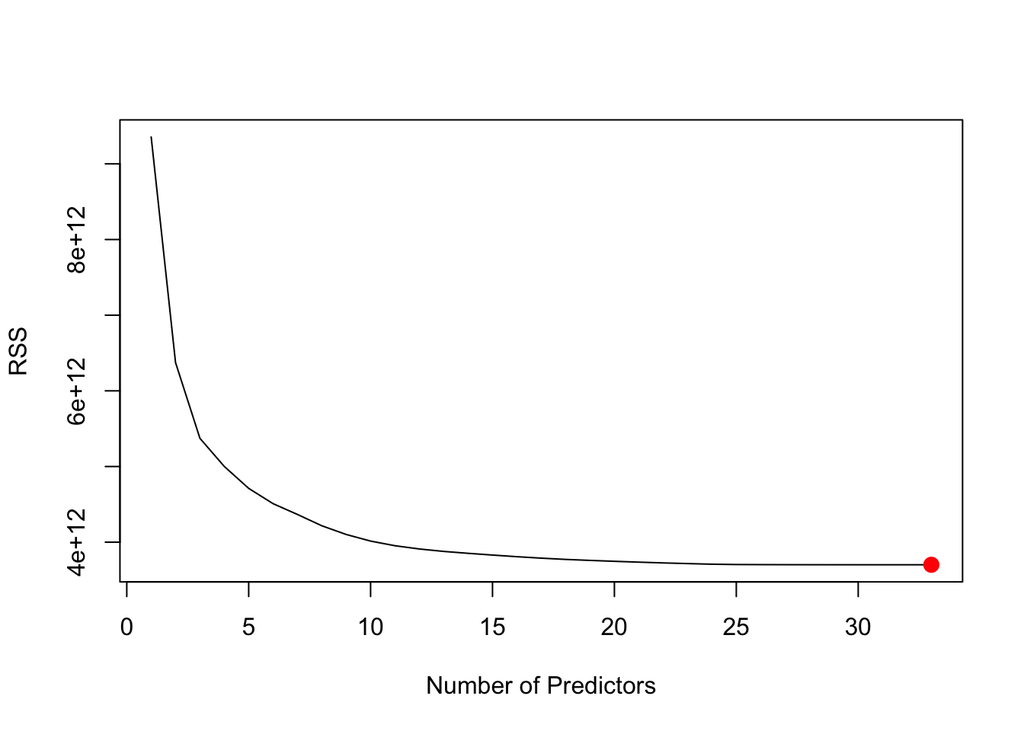

```r
plot(smm$rss,xlab="Number of Predictors", ylab="RSS", type='l')
points(min_rss, smm$rss[min_rss], col="red", cex=2, pch=20)
```

The best model, that is, a model that produces the least RSS is the model that uses 33 predictors. The coefficients of these are as follows:

```r
coef(res, min_rss)
```

```
##        (Intercept)       Lot_Frontage           Lot_Area         Year_Built
##      -1.142977e+07       8.737532e+01       3.141331e-01       3.845931e+02
##     Year_Remod_Add       Mas_Vnr_Area       BsmtFin_SF_1       BsmtFin_SF_2
##       5.129858e+02       3.794721e+01       3.002994e+02      -1.338433e+01
##        Bsmt_Unf_SF      Total_Bsmt_SF       First_Flr_SF    Low_Qual_Fin_SF
##      -1.337146e+01       3.759189e+01       3.554565e-01      -4.417005e+01
##     Bsmt_Full_Bath     Bsmt_Half_Bath          Full_Bath          Half_Bath
##       6.504458e+03      -1.883312e+03       1.949198e+03      -3.471763e+03
##      Bedroom_AbvGr      Kitchen_AbvGr      TotRms_AbvGrd         Fireplaces
##      -1.034286e+04      -3.360632e+04       4.068734e+03       7.084818e+03
##        Garage_Cars        Garage_Area       Wood_Deck_SF      Open_Porch_SF
##       7.737977e+03       2.082670e+01       2.430170e+01      -4.100172e+00
##     Enclosed_Porch Three_season_porch       Screen_Porch          Pool_Area
##       2.974408e+01       8.723251e+00       6.200042e+01      -6.447100e+01
##           Misc_Val            Mo_Sold          Year_Sold          Longitude
##      -9.497111e+00       2.762025e+01      -9.346976e+02      -1.299076e+04
##           Latitude        Gr_Liv_Area
##       2.464128e+05       6.324190e+01
```

#### BIC Plot (Forward Selection)

Plotting the BIC of each Model (Forward Selection)

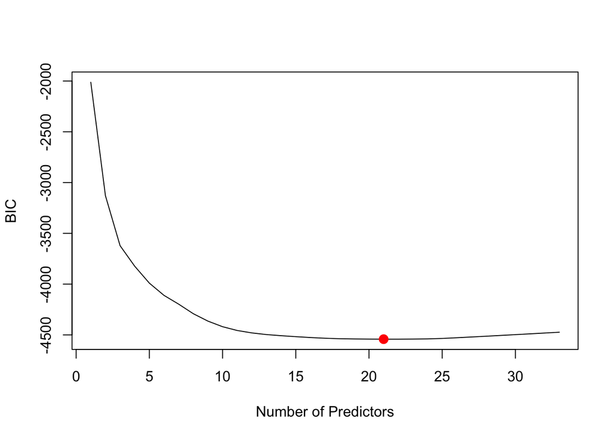

```r
plot(smm$bic,xlab="Number of Predictors", ylab="BIC", type='l')
points(min_bic, smm$bic[min_bic], col="red", cex=2, pch=20)
```

The best model, that is, a model that produces the least BIC is the model that uses 21 predictors. The coefficients of these are as follows:

```r
coef(res, min_bic)
```

```
##    (Intercept)   Lot_Frontage       Lot_Area     Year_Built Year_Remod_Add
##  -1.804094e+06   9.403297e+01   2.439368e-01   3.616190e+02   5.689112e+02
##   Mas_Vnr_Area   BsmtFin_SF_2    Bsmt_Unf_SF  Total_Bsmt_SF Bsmt_Full_Bath
##   4.363806e+01  -1.280552e+01  -1.309842e+01   4.126980e+01   6.192556e+03
## Bsmt_Half_Bath  Kitchen_AbvGr  TotRms_AbvGrd     Fireplaces    Garage_Cars
##  -4.186852e+03  -3.385257e+04   5.606576e+02   9.867642e+03   1.004416e+04
##    Garage_Area   Wood_Deck_SF  Open_Porch_SF      Pool_Area       Misc_Val
##   2.165199e+01   1.963979e+01   1.895785e+00  -5.499532e+01  -9.029755e+00
##        Mo_Sold    Gr_Liv_Area
##   9.536313e+01   5.928065e+01
```

### Backward Selection

Data Initialization and setting up the variables

```r
ames        <- AmesHousing::make_ames()
numericVars <- ames %>% summarise_all(is.numeric) %>% unlist()
ames        <- ames[, numericVars]
NumCols     <- ncol(ames)

res <- regsubsets(Sale_Price ~ .,data=ames, method = "backward",  nvmax=NumCols)
```

```
## Reordering variables and trying again:
```

```r
smm <- summary(res)
smm$rss
```

```
##  [1] 1.146822e+13 7.869601e+12 5.693659e+12 5.277521e+12 4.915896e+12
##  [6] 4.671204e+12 4.481447e+12 4.314304e+12 4.179940e+12 4.092241e+12
## [11] 4.002680e+12 3.946271e+12 3.902998e+12 3.867500e+12 3.842522e+12
## [16] 3.819776e+12 3.796777e+12 3.777550e+12 3.763157e+12 3.750030e+12
## [21] 3.738591e+12 3.727819e+12 3.718299e+12 3.711271e+12 3.707002e+12
## [26] 3.704526e+12 3.703298e+12 3.702482e+12 3.701936e+12 3.701699e+12
## [31] 3.701509e+12 3.701367e+12 3.701352e+12
```

```r
min_rss <- which.min(smm$rss)
min_bic <- which.min(smm$bic)

min_rss
```

```
## [1] 33
```

```r
min_bic
```

```
## [1] 22
```

#### RSS Plot (Backward Selection)

Plotting the RSS of each Model (Backward Selection)

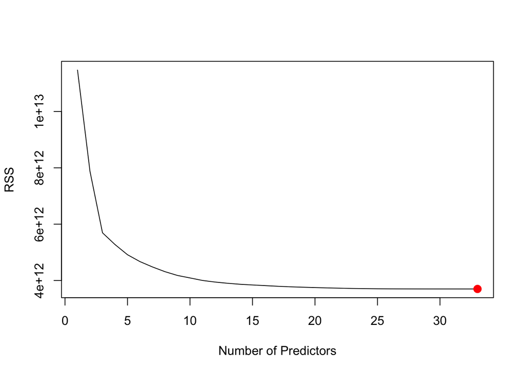

```r
plot(smm$rss,xlab="Number of Predictors", ylab="RSS", type='l')
points(min_rss, smm$rss[min_rss], col="red", cex=2, pch=20)
```

The best model, that is, a model that produces the least RSS is the model that uses 33 predictors. The coefficients of these are as follows:

```r
coef(res, min_rss)
```

```
##        (Intercept)       Lot_Frontage           Lot_Area         Year_Built
##      -1.170805e+07       8.688692e+01       3.250816e-01       3.915167e+02
##     Year_Remod_Add       Mas_Vnr_Area       BsmtFin_SF_1       BsmtFin_SF_2
##       5.250215e+02       3.754647e+01       1.414811e+02      -1.391134e+01
##        Bsmt_Unf_SF      Total_Bsmt_SF       First_Flr_SF      Second_Flr_SF
##      -1.797736e+01       4.219896e+01       6.308277e+01       6.342274e+01
##    Low_Qual_Fin_SF     Bsmt_Half_Bath          Full_Bath          Half_Bath
##       1.994256e+01      -4.985513e+03       1.170822e+03      -3.889125e+03
##      Bedroom_AbvGr      Kitchen_AbvGr      TotRms_AbvGrd         Fireplaces
##      -1.045933e+04      -3.204082e+04       4.031002e+03       7.123055e+03
##        Garage_Cars        Garage_Area       Wood_Deck_SF      Open_Porch_SF
##       8.075298e+03       1.987748e+01       2.550571e+01      -2.347879e+00
##     Enclosed_Porch Three_season_porch       Screen_Porch          Pool_Area
##       3.067302e+01       9.134332e+00       6.239160e+01      -6.435958e+01
##           Misc_Val            Mo_Sold          Year_Sold          Longitude
##      -9.835393e+00       4.225967e+01      -8.848423e+02      -1.570146e+04
##           Latitude        Gr_Liv_Area
##       2.437618e+05       0.000000e+00
```

#### BIC Plot (Backward Selection)

Plotting the BIC of each Model (Backward Selection)

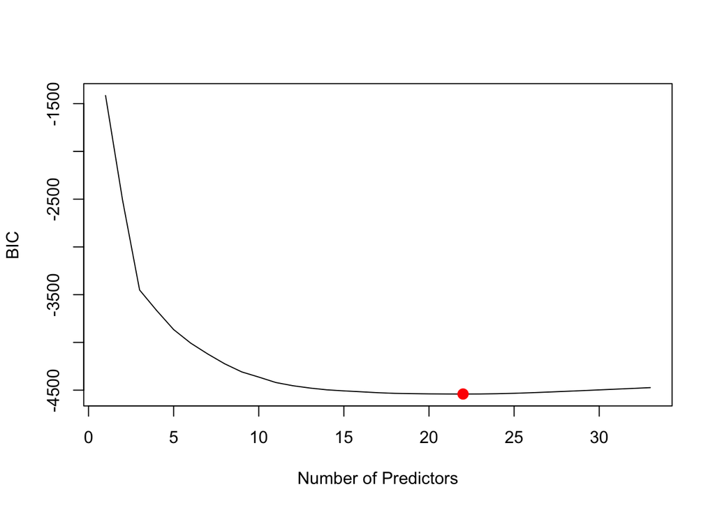

```r
plot(smm$bic,xlab="Number of Predictors", ylab="BIC", type='l')
points(min_bic, smm$bic[min_bic], col="red", cex=2, pch=20)
```

The best model, that is, a model that produces the least BIC is the model that uses 22 predictors. The coefficients of these are as follows:

```r
coef(res, min_bic)
```

```
##    (Intercept)   Lot_Frontage       Lot_Area     Year_Built Year_Remod_Add
##  -1.816554e+06   8.988071e+01   2.252629e-01   3.568215e+02   5.800933e+02
##   Mas_Vnr_Area   BsmtFin_SF_2    Bsmt_Unf_SF  Total_Bsmt_SF   First_Flr_SF
##   4.228330e+01  -1.357431e+01  -1.785513e+01   4.275903e+01   4.067518e+01
##  Second_Flr_SF Bsmt_Half_Bath  Kitchen_AbvGr  TotRms_AbvGrd     Fireplaces
##   3.517944e+01  -7.244059e+03  -3.430550e+04   6.485669e+02   9.556181e+03
##    Garage_Cars    Garage_Area   Wood_Deck_SF  Open_Porch_SF      Pool_Area
##   1.024918e+04   2.015845e+01   2.092499e+01   3.072430e+00  -5.526520e+01
##       Misc_Val        Mo_Sold    Gr_Liv_Area
##  -9.437835e+00   9.540143e+01   2.300514e+01
```